# TAYLOR Tidy Tuesday

Scout Leonard

These Tidy Tuesday analyses and visualizations come from the [Tidy Tuesday Github repository for September 14, 2021](https://github.com/rfordatascience/tidytuesday/tree/master/data/2021/2021-09-14). The data in the repository comes from Data.World through Sean Miller, Billboard.com and Spotify.

I turned 13 years old in the year 2008. This is the same year Taylor Swift’s second album, **Fearless** was released to the world. Taylor wrote and recorded the lyrics, bursting with fairytale imagery and the highs and lows of life as a teenage girl. I was *smitten.* As a teenager, I came to know every lyric of every song and plastered my room in imgages of Swift pulled from magazines.

I’m not at the same level of fandom as I was in 9th grade:

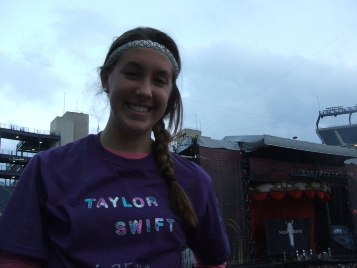

…or even my freshman year of college:

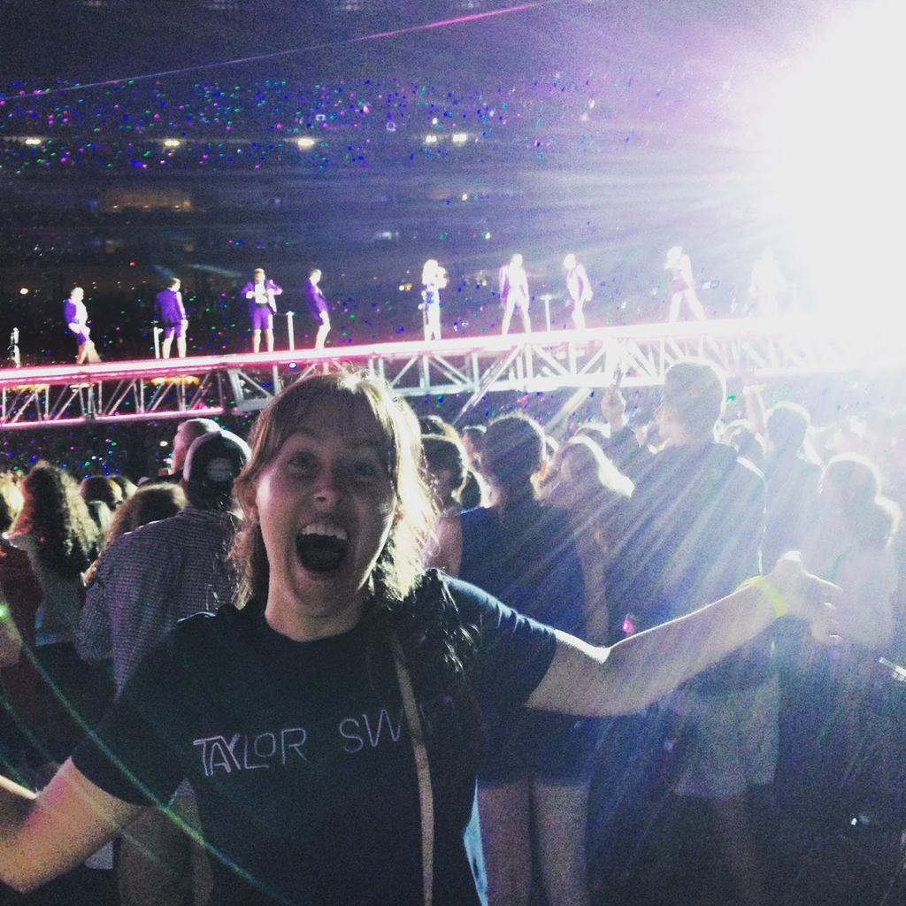

…but I do still listen excitedly when Taylor Swift releases new music and feel nostalgic joy for all of my old favorite songs, from the the slow ballads, like (the **best Swift song of all time**) [All Too Well](https://www.youtube.com/watch?v=F8Jxo15Vfic), to the beltable favorites, like [You Belong With Me](https://www.youtube.com/watch?v=VuNIsY6JdUw).

When I saw that this Tidy Tuesday dataset was rich with TSwift data, I knew it would be fun for me to practice my data wrangling and visualizations with it. What follows are analyses of Taylor Swift songs by album and by audio features. Hopefully fellow Swifty data scientists will find it as *fearless*, *enchanted*, and *wonderstruck* as I do!

# Load Libraries and Read in Data

```r
#read in the data
tuesdata <- tidytuesdayR::tt_load('2021-09-14')
```

```r
audio_features <- tuesdata$audio_features
```

# Wrangle `audio_features` data for Taylor Swift data

The `audio_features` dataset has contains the audio features of nearly 30,000 songs. I’m not sure how the songs were selcted, but in exploring the data, the observation include work from Louis Armstrong to Beyonce Knowles to Dolly Parton to U2. Because I am only interested in Taylor Swift’s music for this analysis, I filtered for only her music below.

Taylor Swift has lots of oddball singles and deluxe albums featuring bonus tracks, which I thought would muddy the data by 1.) including duplicate songs from original albums *and* their deluxe versions and 2.) giving too many albums to compare, and albums that are not truly representative of Taylor’s various “eras.” Her Christmas album, for example, would not be interesting to compare to her main body of work, nor would her singles from the Hunger Games soundtrack. I stick to the main 9 albums here, in chronological order: *Taylor Swift, Fearless, Speak Now, Red, 1989, reputation, Lover, folklore, and evermore.*

Filtering for the more recent two albums, *folklore* and *evermore*, was difficult because the formatting of the data changed between *Lover* and *folklore*. Instead of simply the album names, the `spotify_track_album` column began to include url-like strings of nonsense that did not resemble an album name. I used the function `grepl()` to specify a string within that nonsense, the actual title names, and pull the songs from those albums into my dataset. I then mutated them using `str_detect()` and replaced them with simply the album name!

```r
#create a taylor swift subset with desired albums
tswift_data <- audio_features %>%
  filter(performer == "Taylor Swift") %>%
  filter(spotify_track_album == "Taylor Swift" |
           spotify_track_album == "Fearless" |
           spotify_track_album == "Speak Now" |
           spotify_track_album == "Red" |
           spotify_track_album == "1989" |
           spotify_track_album == "reputation" |
           spotify_track_album == "Lover" |
           grepl("folklore", spotify_track_album) |
           grepl("evermore", spotify_track_album))

#rename folklore and evermore occurances to simply the album names
tswift_data <- tswift_data %>%
  mutate(spotify_track_album = case_when(
    str_detect(spotify_track_album, "folklore") ~ "folklore",
    str_detect(spotify_track_album, "evermore") ~ "evermore",
    TRUE ~ spotify_track_album
  ))
```

Then, I made a new dataframe, `data_by_album`, with a `group_by()` album name and `summarize()` to return mean audio features for each album. This prepared a dataset I could use to compare sound qualities across Swift’s discography.

I also defined levels for the albums based on year of release. This way, the albums would appear in chronological order in my visualizations, which made more sense in my Swifty brain for comparing all 9 albums.

```r
#group by album and summarize mean audio features per album
data_by_album <- tswift_data %>%
  group_by(spotify_track_album) %>%
  summarise(mean_danceability = mean(danceability),
            mean_energy = mean(energy),
            mean_key = mean(key),
            mean_loudness = mean(loudness),
            mean_speechiness = mean(speechiness),
            mean_acousticness = mean(acousticness),
            mean_instrumentalness = mean(instrumentalness),
            mean_liveness = mean(liveness),
            mean_valence =  mean(valence),
            mean_tempo = mean(tempo),
            mean_popularity = mean(spotify_track_popularity))

#define levels based on album chronology
data_by_album$spotify_track_album = factor(data_by_album$spotify_track_album,
                                           levels = c("Taylor Swift",
                                                      "Fearless",
                                                      "Speak Now",
                                                      "Red",
                                                      "1989",
                                                     "reputation",
                                                     "Lover",
                                                     "folklore",
                                                     "evermore"))
```

## Data Viz and Analysis

### Some More Extensive Exploration!

I used the Google Chrome plugin “color picker,” to pick colors from the album art of each of Taylor’s albums for use in these data visualizations. If you don’t like the color schemes, you’ll have to talk to the Swift franchise; sorry!

```r
album_cols <- c("#0BA5D7", "#D8BD7D", "#7D4884", "#AE1848", "#96818F", "#0A0A0A", "#FEB5DC", "#919191", "#D85F2E")
```

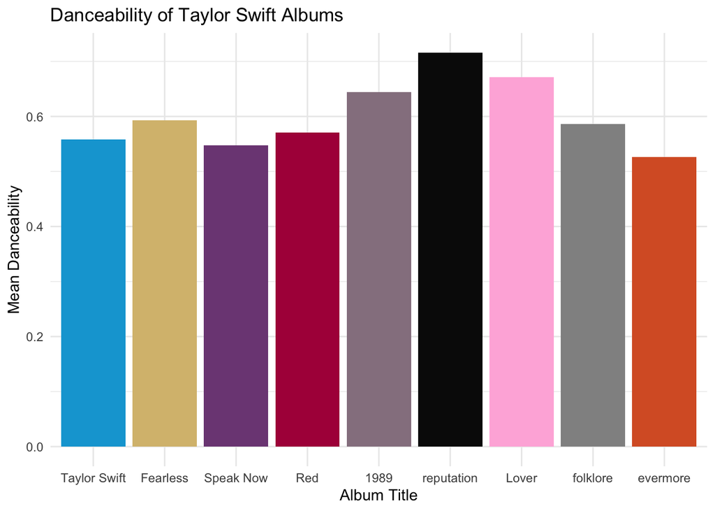

```r
danceability <- ggplot(data = data_by_album, aes(x = spotify_track_album, y = mean_danceability)) +
  geom_histogram(stat = "identity", aes(fill = spotify_track_album)) +
  theme_minimal() +
  theme(legend.position = "none") +
  labs(title = "Danceability of Taylor Swift Albums",
       x = "Album Title",
       y = "Mean Danceability") +
  scale_fill_manual(values = album_cols)

danceability
```

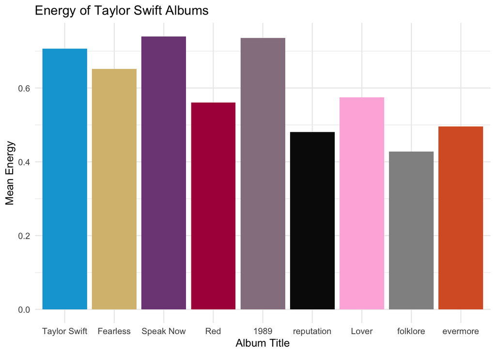

```r
energy <- ggplot(data = data_by_album, aes(x = spotify_track_album, y = mean_energy)) +
  geom_histogram(stat = "identity", aes(fill = spotify_track_album)) +
  theme_minimal() +
  theme(legend.position = "none") +
  labs(title = "Energy of Taylor Swift Albums",
       x = "Album Title",
       y = "Mean Energy") +
  scale_fill_manual(values = album_cols)

energy
```

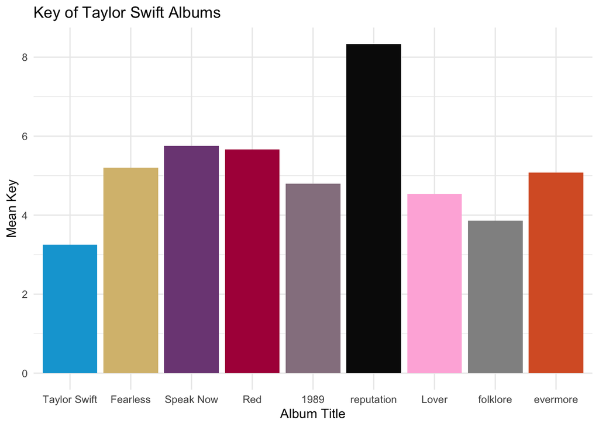

```r
key <- ggplot(data = data_by_album, aes(x = spotify_track_album, y = mean_key)) +
  geom_histogram(stat = "identity", aes(fill = spotify_track_album)) +
  theme_minimal() +
  theme(legend.position = "none") +
  labs(title = "Key of Taylor Swift Albums",
       x = "Album Title",
       y = "Mean Key") +
  scale_fill_manual(values = album_cols)

key
```

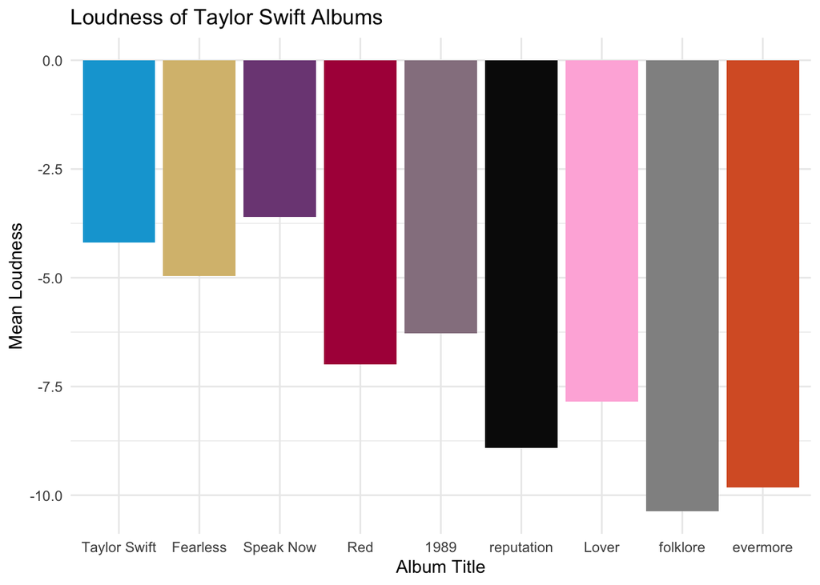

```r
loudness <- ggplot(data = data_by_album, aes(x = spotify_track_album, y = mean_loudness)) +
  geom_histogram(stat = "identity", aes(fill = spotify_track_album)) +
  theme_minimal() +
  theme(legend.position = "none") +
  labs(title = "Loudness of Taylor Swift Albums",
       x = "Album Title",
       y = "Mean Loudness") +
  scale_fill_manual(values = album_cols)

loudness
```

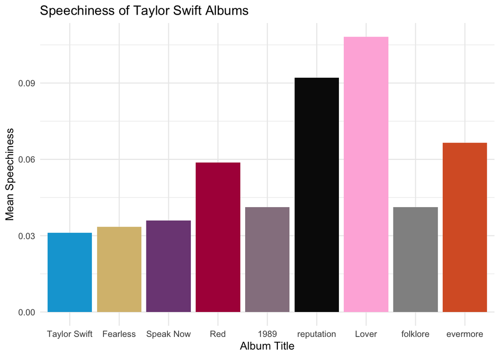

```r
speechiness <- ggplot(data = data_by_album, aes(x = spotify_track_album, y = mean_speechiness)) +
  geom_histogram(stat = "identity", aes(fill = spotify_track_album)) +
  theme_minimal() +
  theme(legend.position = "none") +
  labs(title = "Speechiness of Taylor Swift Albums",
       x = "Album Title",
       y = "Mean Speechiness") +
  scale_fill_manual(values = album_cols)

speechiness
```

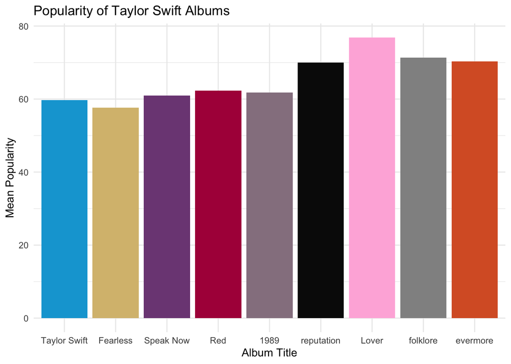

```r
popularity <- ggplot(data = data_by_album, aes(x = spotify_track_album, y = mean_popularity)) +
  geom_histogram(stat = "identity", aes(fill = spotify_track_album)) +
  theme_minimal() +
  theme(legend.position = "none") +
  labs(title = "Popularity of Taylor Swift Albums",
       x = "Album Title",
       y = "Mean Popularity") +
  scale_fill_manual(values = album_cols)

popularity
```

```r
ols_danceability <- lm(data = tswift_data, spotify_track_popularity ~ danceability)

summary(ols_danceability) %>%
  tidy() %>%
  gt()
```

| term | estimate | std.error | statistic | p.value |
| --- | --- | --- | --- | --- |
| (Intercept) | 63.174235 | 4.754202 | 13.288084 | 1.069703e-20 |
| danceability | 8.136838 | 7.758330 | 1.048787 | 2.979358e-01 |

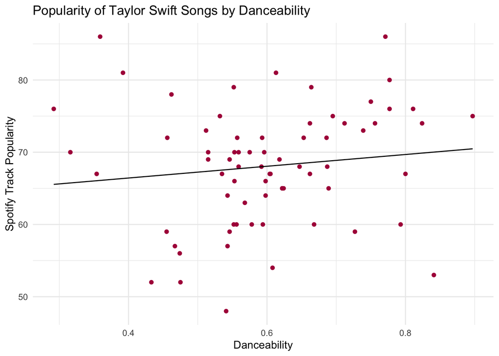

```r
ggplot(data = tswift_data, aes(x = danceability, y = spotify_track_popularity)) +
  geom_point(color = "#AE1848") +
  geom_line(data = ols_danceability, aes(y = .fitted)) +
  theme_minimal() +
  labs(title = "Popularity of Taylor Swift Songs by Danceability",
       x = "Danceability",
       y = "Spotify Track Popularity")
```

```r
ols_tempo <- lm(data = tswift_data, spotify_track_popularity ~ tempo)

summary(ols_tempo) %>%
  tidy() %>%
  gt()
```

| term | estimate | std.error | statistic | p.value |
| --- | --- | --- | --- | --- |
| (Intercept) | 73.37083397 | 4.12193465 | 17.800096 | 1.704171e-27 |
| tempo | -0.04473769 | 0.03374115 | -1.325909 | 1.892427e-01 |

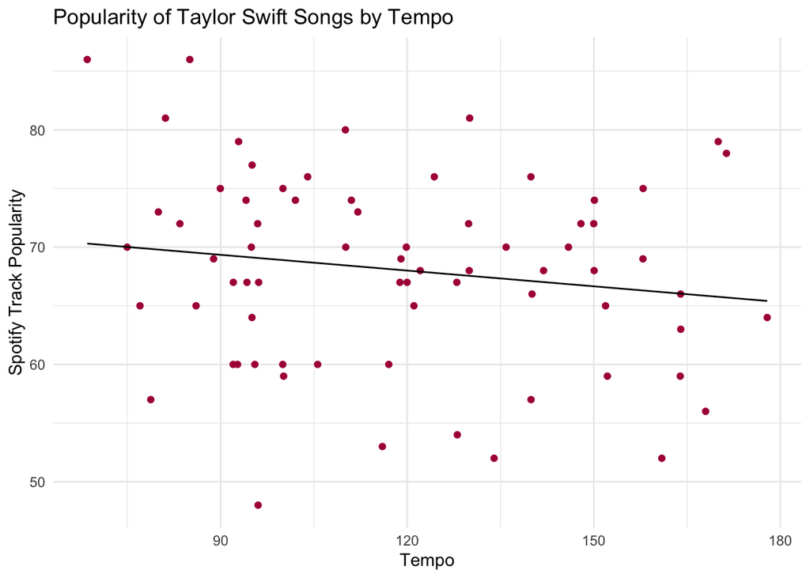

```r
ggplot(data = tswift_data, aes(x = tempo, y = spotify_track_popularity)) +
  geom_point(color = "#AE1848") +
  geom_line(data = ols_tempo, aes(y = .fitted)) +
  theme_minimal() +
  labs(title = "Popularity of Taylor Swift Songs by Tempo",
       x = "Tempo",
       y = "Spotify Track Popularity")
```

```r
ols_acousticness <- lm(data = tswift_data, spotify_track_popularity ~ acousticness)

summary(ols_acousticness) %>%
  tidy() %>%
  gt()
```

| term | estimate | std.error | statistic | p.value |
| --- | --- | --- | --- | --- |
| (Intercept) | 65.118603 | 1.419408 | 45.877289 | 1.970049e-53 |
| acousticness | 7.412888 | 2.716302 | 2.729036 | 8.052126e-03 |

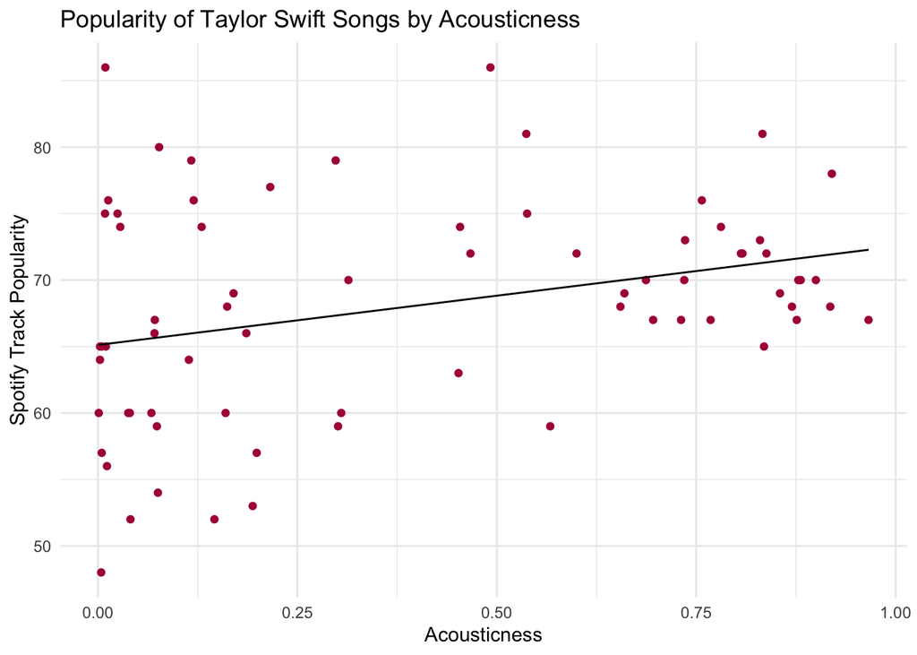

```r
ggplot(data = tswift_data, aes(x = acousticness, y = spotify_track_popularity)) +
  geom_point(color = "#AE1848") +
  geom_line(data = ols_acousticness, aes(y = .fitted)) +
  theme_minimal() +
  labs(title = "Popularity of Taylor Swift Songs by Acousticness",
       x = "Acousticness",
       y = "Spotify Track Popularity")
```

```r
ols_speechiness <- lm(data = tswift_data, spotify_track_popularity ~ speechiness)

summary(ols_speechiness) %>%
  tidy() %>%
  gt()
```

| term | estimate | std.error | statistic | p.value |
| --- | --- | --- | --- | --- |
| (Intercept) | 65.93397 | 1.231724 | 53.529839 | 6.260601e-58 |
| speechiness | 35.03886 | 13.359345 | 2.622798 | 1.072452e-02 |

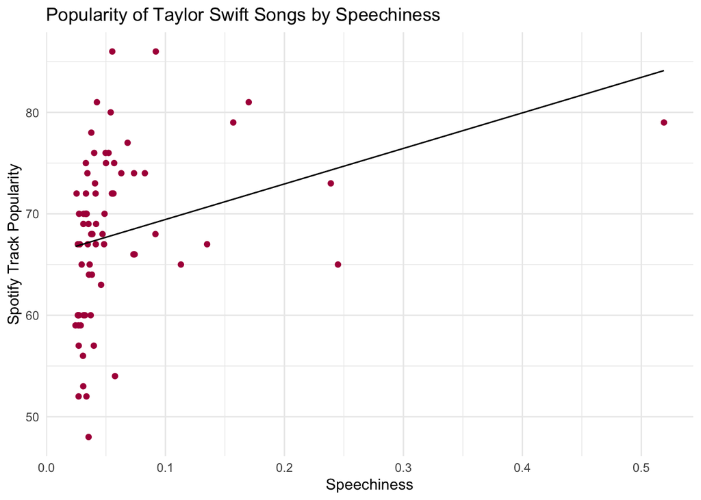

```r
ggplot(data = tswift_data, aes(x = speechiness, y = spotify_track_popularity)) +
  geom_point(color = "#AE1848") +
  geom_line(data = ols_speechiness, aes(y = .fitted)) +
  theme_minimal() +
  labs(title = "Popularity of Taylor Swift Songs by Speechiness",
       x = "Speechiness",
       y = "Spotify Track Popularity")
```